# morphology-analysis_final

##### Residual Comparisons

- STEP FOUR: plot the mean of the |residuals| for both species, for all traits

```r
library(ggbeeswarm)
library(dplyr)
```

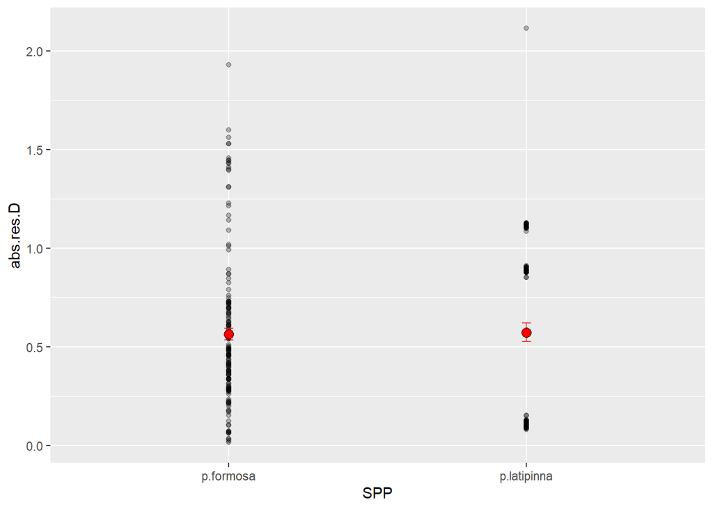

```r
ggplot(raw4, aes(SPP, abs.res.D)) +
  geom_point(alpha=0.3) +
  stat_summary(fun.data=function(x){mean_cl_normal(x, conf.int=.683)}, geom="errorbar",
               width=0.03, colour="red", alpha=0.7) +
  stat_summary(fun=mean, geom="point", fill="red", pch=21, size=3)
```

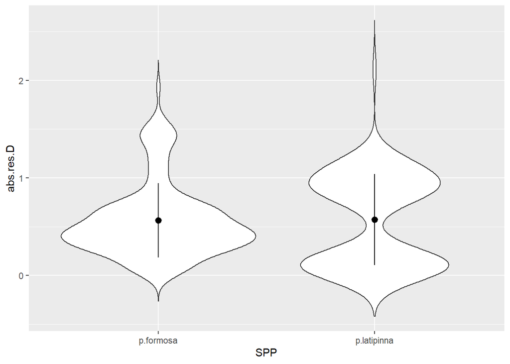

```r
scatter_violin <- ggplot(data=raw4, aes(x=SPP, y=abs.res.D)) +
  geom_violin(trim = FALSE) +
  stat_summary(
    fun.data = "mean_sdl",  fun.args = list(mult = 1),
    geom = "pointrange", color = "black"
    )

print(scatter_violin)
```

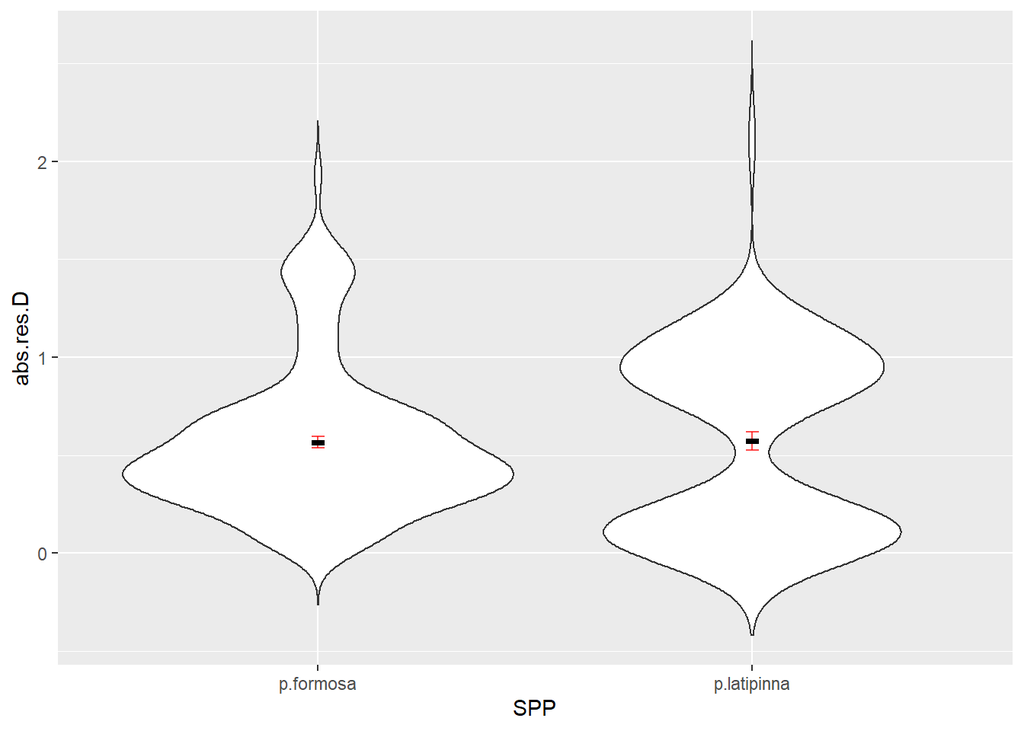

```r
scatter_violin1 <- ggplot(data=raw4, aes(x=SPP, y=abs.res.D)) +
  geom_violin(trim = FALSE) +
  stat_summary(fun.data=function(x){mean_cl_normal(x, conf.int=.683)}, geom="errorbar",
               width=0.03, colour="red", alpha=0.7) +
  stat_summary(fun=mean, geom="crossbar", fill="red", width=0.03)

print(scatter_violin1)
```

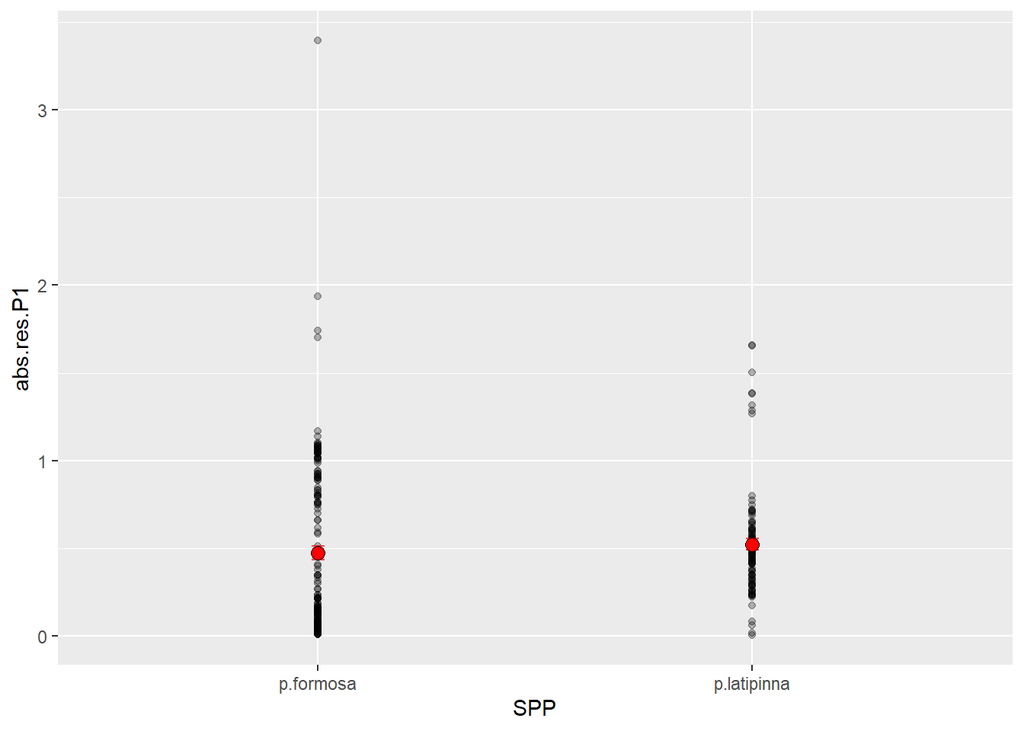

```r
ggplot(raw4, aes(SPP, abs.res.P1)) +
  geom_point(alpha=0.3) +
  stat_summary(fun.data=function(x){mean_cl_normal(x, conf.int=.683)}, geom="errorbar",
               width=0.03, colour="red", alpha=0.7) +
  stat_summary(fun=mean, geom="point", fill="red", pch=21, size=3)
```

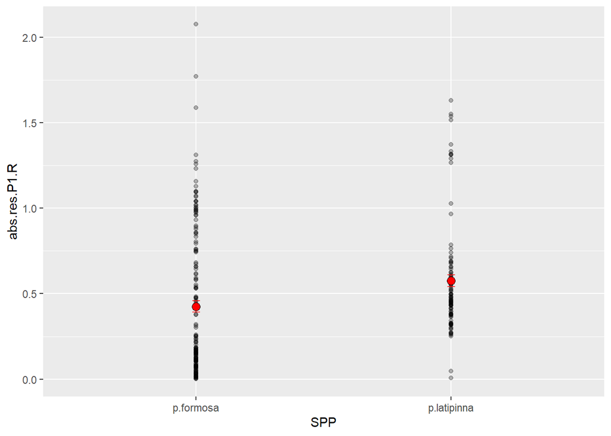

```r
ggplot(raw4, aes(SPP, abs.res.P1.R)) +
  geom_point(alpha=0.3) +
  stat_summary(fun.data=function(x){mean_cl_normal(x, conf.int=.683)}, geom="errorbar",
               width=0.03, colour="red", alpha=0.7) +
  stat_summary(fun=mean, geom="point", fill="red", pch=21, size=3)
```

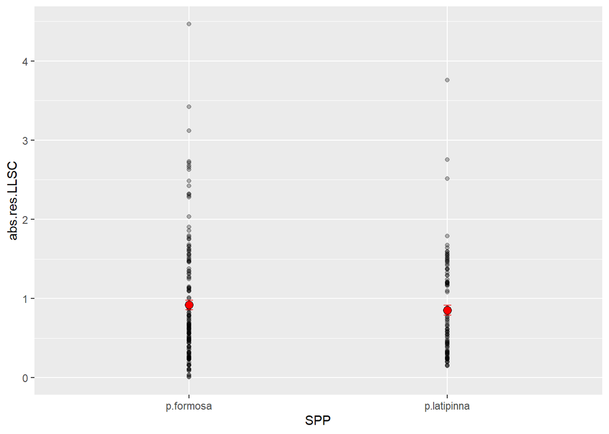

```r
ggplot(raw4, aes(SPP, abs.res.LLSC)) +
  geom_point(alpha=0.3) +
  stat_summary(fun.data=function(x){mean_cl_normal(x, conf.int=.683)}, geom="errorbar",
               width=0.03, colour="red", alpha=0.7) +
  stat_summary(fun=mean, geom="point", fill="red", pch=21, size=3)
```

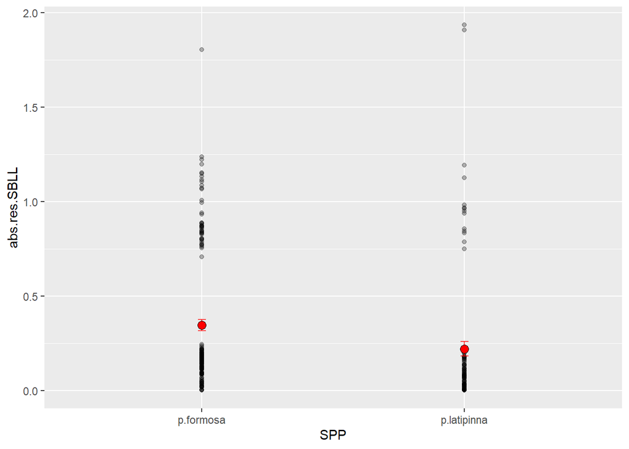

```r
ggplot(raw4, aes(SPP, abs.res.SBLL)) +
  geom_point(alpha=0.3) +
  stat_summary(fun.data=function(x){mean_cl_normal(x, conf.int=.683)}, geom="errorbar",
               width=0.03, colour="red", alpha=0.7) +
  stat_summary(fun=mean, geom="point", fill="red", pch=21, size=3)
```

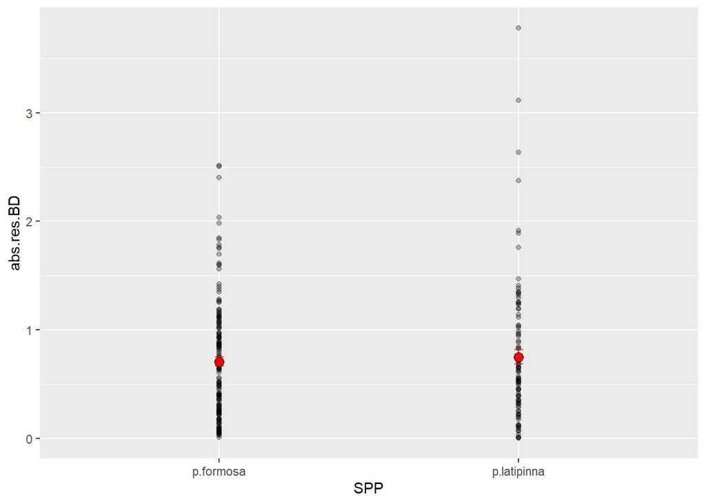

```r
ggplot(raw4, aes(SPP, abs.res.BD)) +
  geom_point(alpha=0.3) +
  stat_summary(fun.data=function(x){mean_cl_normal(x, conf.int=.683)}, geom="errorbar",
               width=0.03, colour="red", alpha=0.7) +
  stat_summary(fun=mean, geom="point", fill="red", pch=21, size=3)
```

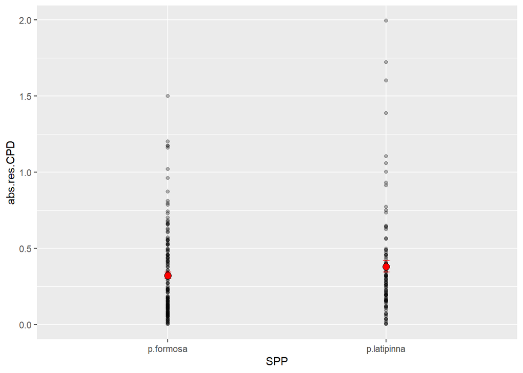

```r
ggplot(raw4, aes(SPP, abs.res.CPD)) +
  geom_point(alpha=0.3) +
  stat_summary(fun.data=function(x){mean_cl_normal(x, conf.int=.683)}, geom="errorbar",
               width=0.03, colour="red", alpha=0.7) +
  stat_summary(fun=mean, geom="point", fill="red", pch=21, size=3)
```

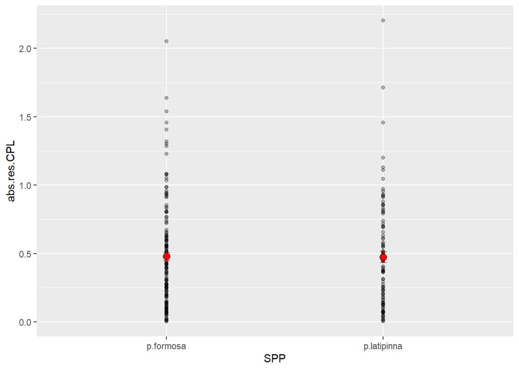

```r
ggplot(raw4, aes(SPP, abs.res.CPL)) +
  geom_point(alpha=0.3) +
  stat_summary(fun.data=function(x){mean_cl_normal(x, conf.int=.683)}, geom="errorbar",
               width=0.03, colour="red", alpha=0.7) +
  stat_summary(fun=mean, geom="point", fill="red", pch=21, size=3)
```

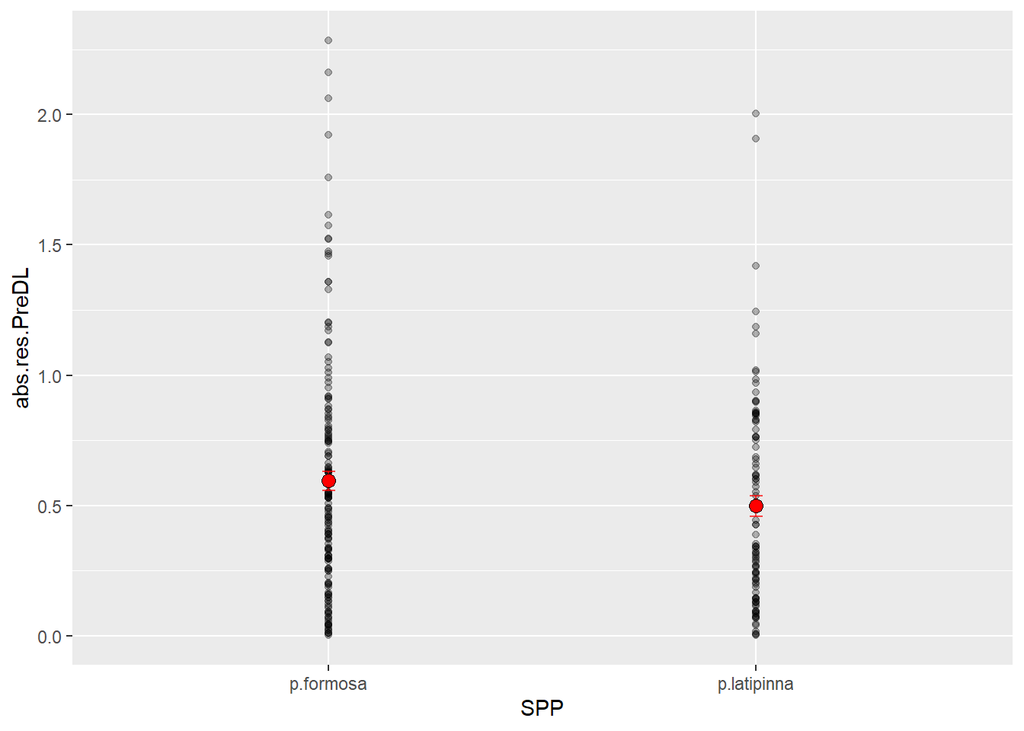

```r
ggplot(raw4, aes(SPP, abs.res.PreDL)) +
  geom_point(alpha=0.3) +
  stat_summary(fun.data=function(x){mean_cl_normal(x, conf.int=.683)}, geom="errorbar",
               width=0.03, colour="red", alpha=0.7) +
  stat_summary(fun=mean, geom="point", fill="red", pch=21, size=3)
```

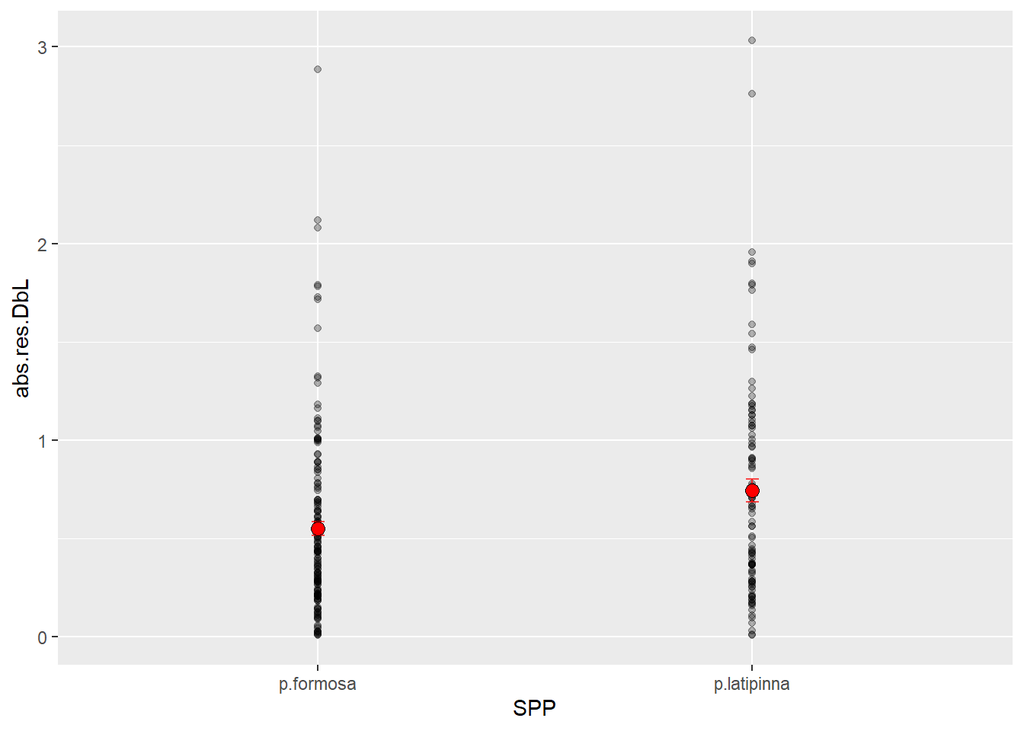

```r
ggplot(raw4, aes(SPP, abs.res.DbL)) +
  geom_point(alpha=0.3) +
  stat_summary(fun.data=function(x){mean_cl_normal(x, conf.int=.683)}, geom="errorbar",
               width=0.03, colour="red", alpha=0.7) +
  stat_summary(fun=mean, geom="point", fill="red", pch=21, size=3)
```

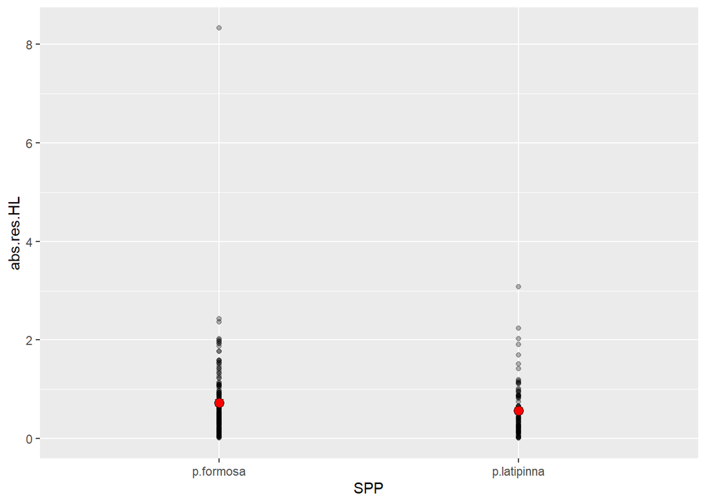

```r
ggplot(raw4, aes(SPP, abs.res.HL)) +
  geom_point(alpha=0.3) +
  stat_summary(fun.data=function(x){mean_cl_normal(x, conf.int=.683)}, geom="errorbar",
               width=0.03, colour="red", alpha=0.7) +
  stat_summary(fun=mean, geom="point", fill="red", pch=21, size=3)
```

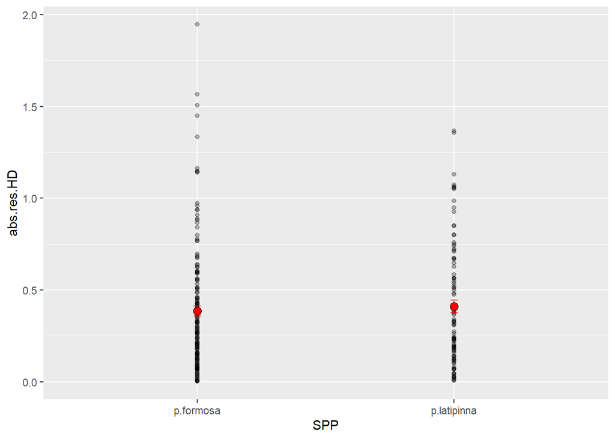

```r
ggplot(raw4, aes(SPP, abs.res.HD)) +
  geom_point(alpha=0.3) +
  stat_summary(fun.data=function(x){mean_cl_normal(x, conf.int=.683)}, geom="errorbar",
               width=0.03, colour="red", alpha=0.7) +
  stat_summary(fun=mean, geom="point", fill="red", pch=21, size=3)
```

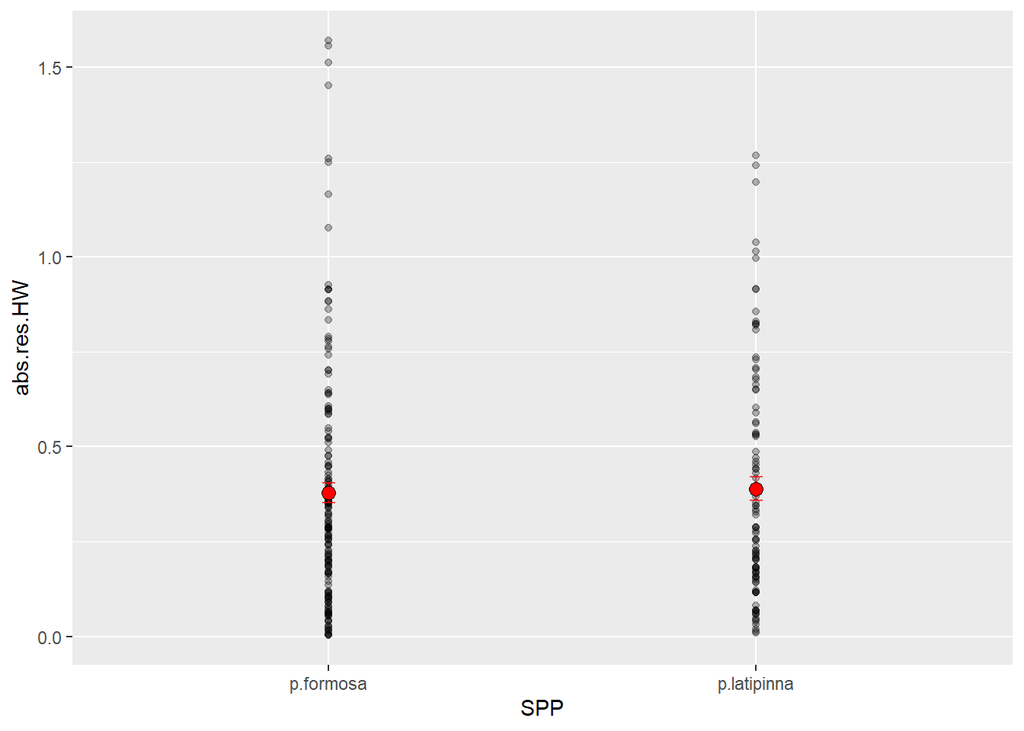

```r
ggplot(raw4, aes(SPP, abs.res.HW)) +
  geom_point(alpha=0.3) +
  stat_summary(fun.data=function(x){mean_cl_normal(x, conf.int=.683)}, geom="errorbar",
               width=0.03, colour="red", alpha=0.7) +
  stat_summary(fun=mean, geom="point", fill="red", pch=21, size=3)
```

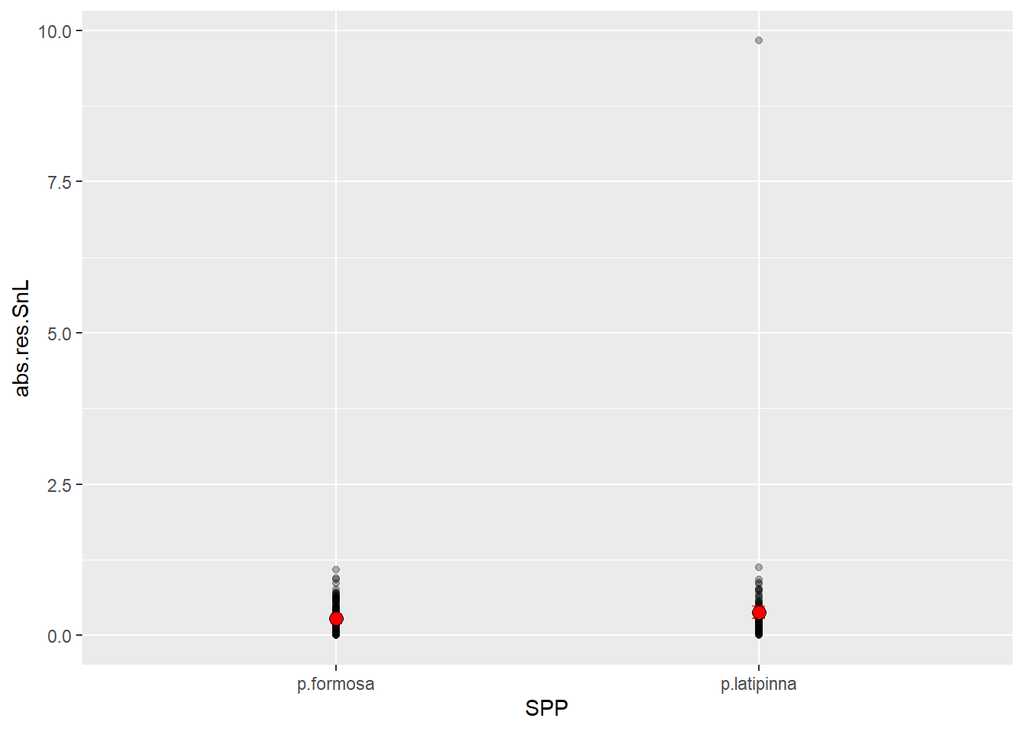

```r
ggplot(raw4, aes(SPP, abs.res.SnL)) +
  geom_point(alpha=0.3) +
  stat_summary(fun.data=function(x){mean_cl_normal(x, conf.int=.683)}, geom="errorbar",
               width=0.03, colour="red", alpha=0.7) +
  stat_summary(fun=mean, geom="point", fill="red", pch=21, size=3)
```

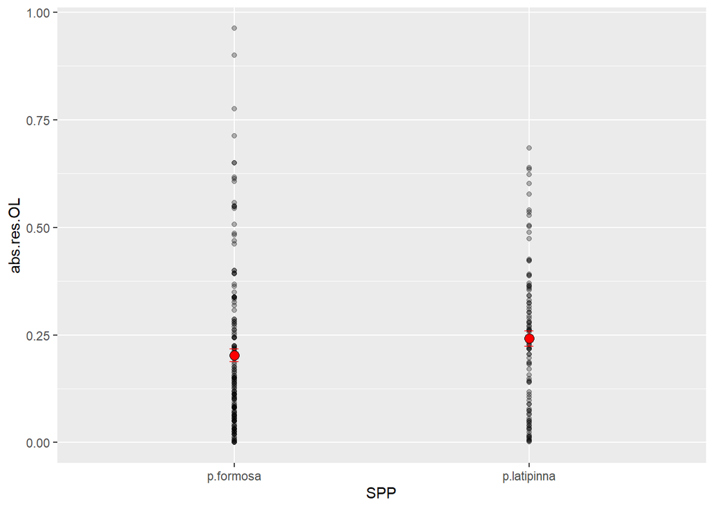

```r
ggplot(raw4, aes(SPP, abs.res.OL)) +
  geom_point(alpha=0.3) +
  stat_summary(fun.data=function(x){mean_cl_normal(x, conf.int=.683)}, geom="errorbar",
               width=0.03, colour="red", alpha=0.7) +
  stat_summary(fun=mean, geom="point", fill="red", pch=21, size=3)
```

#### F tests to compare species

```
-   will do two-tailed and check out the means to infer direction (see beginning for trait means w/o body correction)
-   this will only be for the traits that did not have a significant regression compared to SL (so P2s, A, SALL, SBDF, and FLA)
```

```
##
##  F test to compare two variances
##
## data:  lat$P2.L and form$P2.L
## F = 1.5948, num df = 115, denom df = 184, p-value = 0.004761
## alternative hypothesis: true ratio of variances is not equal to 1
## 95 percent confidence interval:
##  1.152908 2.234529
## sample estimates:
## ratio of variances
##           1.594828
```

```
##
##  F test to compare two variances
##
## data:  lat$P2.R and form$P2.R
## F = 15.865, num df = 115, denom df = 184, p-value < 2.2e-16
## alternative hypothesis: true ratio of variances is not equal to 1
## 95 percent confidence interval:
##  11.46893 22.22870
## sample estimates:
## ratio of variances
##           15.86507
```

```
##
##  F test to compare two variances
##
## data:  lat$A and form$A
## F = 1.637, num df = 114, denom df = 184, p-value = 0.002933
## alternative hypothesis: true ratio of variances is not equal to 1
## 95 percent confidence interval:
##  1.182502 2.296022
## sample estimates:
## ratio of variances
##           1.636995
```

```
##
##  F test to compare two variances
##
## data:  lat$SALL and form$SALL
## F = 0.96921, num df = 113, denom df = 180, p-value = 0.8644
## alternative hypothesis: true ratio of variances is not equal to 1
## 95 percent confidence interval:
##  0.6984328 1.3624433
## sample estimates:
## ratio of variances
##          0.9692065
```

```
##
##  F test to compare two variances
##
## data:  lat$SBDF and form$SBDF
## F = 17.075, num df = 105, denom df = 172, p-value < 2.2e-16
## alternative hypothesis: true ratio of variances is not equal to 1
## 95 percent confidence interval:
##  12.18306 24.28208
## sample estimates:
## ratio of variances
##           17.07499
```

[output not shown]

#### T tests to compare species

- will do two-tailed and check out the means to infer direction (see beginning for trait means w/o body correction)
- this will be for the traits that *did* have a significant regression compared to SL; will be using the absolute value residuals.

```
##
##  Welch Two Sample t-test
##
## data:  abs.lat.D1 and abs.form.D1
## t = 0.13704, df = 176.65, p-value = 0.8912
## alternative hypothesis: true difference in means is not equal to 0
## 95 percent confidence interval:
##  -0.1020043  0.1172282
## sample estimates:
## mean of x mean of y
## 0.5730614 0.5654495
```

```
##
##  Welch Two Sample t-test
##
## data:  abs.lat.P11 and abs.form.P11
## t = 0.9621, df = 258.86, p-value = 0.3369
## alternative hypothesis: true difference in means is not equal to 0
## 95 percent confidence interval:
##  -0.0506543  0.1474391
## sample estimates:
## mean of x mean of y
## 0.5241042 0.4757118
```

```
##
##  Welch Two Sample t-test
##
## data:  abs.lat.P1.R1 and abs.form.P1.R1
## t = 3.2009, df = 241.96, p-value = 0.001553
## alternative hypothesis: true difference in means is not equal to 0
## 95 percent confidence interval:
##  0.05828306 0.24479677
## sample estimates:
## mean of x mean of y
## 0.5764223 0.4248824
```

```
##
##  Welch Two Sample t-test
##
## data:  abs.lat.LLSC1 and abs.form.LLSC1
## t = -0.73668, df = 237.47, p-value = 0.462
## alternative hypothesis: true difference in means is not equal to 0
## 95 percent confidence interval:
##  -0.2345681  0.1068826
## sample estimates:
## mean of x mean of y
## 0.8542434 0.9180862
```

```
##
##  Welch Two Sample t-test
##
## data:  abs.lat.SBLL1 and abs.form.SBLL1
## t = -2.6011, df = 205.46, p-value = 0.009969
## alternative hypothesis: true difference in means is not equal to 0
## 95 percent confidence interval:
##  -0.21996396 -0.03028177
## sample estimates:
## mean of x mean of y
## 0.2202907 0.3454136
```

```
##
##  Welch Two Sample t-test
##
## data:  abs.lat.BD1 and abs.form.BD1
## t = 0.54424, df = 179.23, p-value = 0.587
## alternative hypothesis: true difference in means is not equal to 0
## 95 percent confidence interval:
##  -0.1112487  0.1959853
## sample estimates:
## mean of x mean of y
## 0.7505625 0.7081942
```

```
##
##  Welch Two Sample t-test
##
## data:  abs.lat.CPD1 and abs.form.CPD1
## t = 1.4017, df = 169.77, p-value = 0.1628
## alternative hypothesis: true difference in means is not equal to 0
## 95 percent confidence interval:
##  -0.02402447  0.14169068
## sample estimates:
## mean of x mean of y
## 0.3818484 0.3230152
```

```
##
##  Welch Two Sample t-test
##
## data:  abs.lat.CPL1 and abs.form.CPL1
## t = -0.096141, df = 196.73, p-value = 0.9235
## alternative hypothesis: true difference in means is not equal to 0
## 95 percent confidence interval:
##  -0.1013114  0.0918926
## sample estimates:
## mean of x mean of y
## 0.4732959 0.4780053
```

```
##
##  Welch Two Sample t-test
##
## data:  abs.lat.PreDL1 and abs.form.PreDL1
## t = -1.7918, df = 229.75, p-value = 0.07448
## alternative hypothesis: true difference in means is not equal to 0
## 95 percent confidence interval:
##  -0.203118150  0.009638355
## sample estimates:
## mean of x mean of y
## 0.4981655 0.5949054
```

```
##
##  Welch Two Sample t-test
##
## data:  abs.lat.DbL1 and abs.form.DbL1
## t = 2.8199, df = 171.11, p-value = 0.005371
## alternative hypothesis: true difference in means is not equal to 0
## 95 percent confidence interval:
##  0.05794543 0.32834237
## sample estimates:
## mean of x mean of y
## 0.7429867 0.5498428
```

```
##
##  Welch Two Sample t-test
##
## data:  abs.lat.HL1 and abs.form.HL1
## t = -1.9946, df = 258.6, p-value = 0.04714
## alternative hypothesis: true difference in means is not equal to 0
## 95 percent confidence interval:
##  -0.32539709 -0.00208364
## sample estimates:
## mean of x mean of y
## 0.5598896 0.7236299
```

```
##
##  Welch Two Sample t-test
##
## data:  abs.lat.HD1 and abs.form.HD1
## t = 0.56735, df = 211.31, p-value = 0.5711
## alternative hypothesis: true difference in means is not equal to 0
## 95 percent confidence interval:
##  -0.06060915  0.10959649
## sample estimates:
## mean of x mean of y
## 0.4104106 0.3859169
```

```
##
##  Welch Two Sample t-test
##
## data:  abs.lat.HW1 and abs.form.HW1
## t = 0.27216, df = 215.06, p-value = 0.7858
## alternative hypothesis: true difference in means is not equal to 0
## 95 percent confidence interval:
##  -0.06821417  0.09006958
## sample estimates:
## mean of x mean of y
## 0.3893030 0.3783753
```

```
##
##  Welch Two Sample t-test
##
## data:  abs.lat.SnL1 and abs.form.SnL1
## t = 1.0014, df = 103.66, p-value = 0.3189
## alternative hypothesis: true difference in means is not equal to 0
## 95 percent confidence interval:
##  -0.09871261  0.30011140
## sample estimates:
## mean of x mean of y
## 0.3845849 0.2838856
```

```
##
##  Welch Two Sample t-test
##
## data:  abs.lat.OL1 and abs.form.OL1
## t = 1.7319, df = 217.78, p-value = 0.08472
## alternative hypothesis: true difference in means is not equal to 0
## 95 percent confidence interval:
##  -0.005464593  0.084639299
## sample estimates:
## mean of x mean of y
## 0.2417447 0.2021573
```

#### Summary of variance results

```r
average.table <- matrix(c(ttest.abs.D1$p.value, mean(abs.lat.D1, na.rm = TRUE), mean(abs.form.D1, na.rm = TRUE), ttest.abs.P11$p.value, mean(abs.lat.P11, na.rm = TRUE), mean(abs.form.P11, na.rm = TRUE), var.rig.pel$p.value, mean(lat$P2.R, na.rm = TRUE), mean(form$P2.R, na.rm = TRUE), var.left.pel$p.value, mean(lat$P2.L, na.rm = TRUE), mean(form$P2.L, na.rm = TRUE), var.anal$p.value, mean(lat$A, na.rm = TRUE), mean(form$A, na.rm = TRUE), ttest.abs.P1.R1$p.value, mean(abs.lat.P1.R1, na.rm = TRUE), mean(abs.form.P1.R1, na.rm = TRUE), ttest.abs.LLSC1$p.value, mean(abs.lat.LLSC1, na.rm = TRUE), mean(abs.form.LLSC1, na.rm = TRUE), var.sca.ab.ll$p.value, mean(lat$SALL, na.rm = TRUE), mean(form$SALL, na.rm = TRUE), ttest.abs.SBLL1$p.value, mean(abs.lat.SBLL1, na.rm = TRUE), mean(abs.form.SBLL1, na.rm = TRUE), var.sca.df$p.value, mean(lat$SBDF, na.rm = TRUE), mean(form$SBDF, na.rm = TRUE), ttest.abs.BD1$p.value, mean(abs.lat.BD1, na.rm = TRUE), mean(abs.form.BD1, na.rm = TRUE), ttest.abs.CPD1$p.value, mean(abs.lat.CPD1, na.rm = TRUE), mean(abs.form.CPD1, na.rm = TRUE), ttest.abs.CPL1$p.value, mean(abs.lat.CPL1, na.rm = TRUE), mean(abs.form.CPL1, na.rm = TRUE), ttest.abs.PreDL1$p.value, mean(abs.lat.PreDL1, na.rm = TRUE), mean(abs.form.PreDL1, na.rm = TRUE), ttest.abs.DbL1$p.value, mean(abs.lat.DbL1, na.rm = TRUE), mean(abs.form.DbL1, na.rm = TRUE), ttest.abs.HL1$p.value, mean(abs.lat.HL1, na.rm = TRUE), mean(abs.form.HL1, na.rm = TRUE), ttest.abs.HD1$p.value, mean(abs.lat.HD1, na.rm = TRUE), mean(abs.form.HD1, na.rm = TRUE), ttest.abs.HW1$p.value, mean(abs.lat.HW1, na.rm = TRUE), mean(abs.form.HW1, na.rm = TRUE), ttest.abs.SnL1$p.value, mean(abs.lat.SnL1, na.rm = TRUE), mean(abs.form.SnL1, na.rm = TRUE), ttest.abs.OL1$p.value, mean(abs.lat.OL1, na.rm = TRUE), mean(abs.form.OL1, na.rm = TRUE), var.flu.asy$p.value, mean(lat$FLA, na.rm = TRUE), mean(form$FLA, na.rm = TRUE)), ncol=3, byrow=TRUE)

colnames(average.table)<- c('p-value for variance', 'lat mean', 'form mean')

rownames(average.table) <- c('dorsal rays', 'L pect rays', 'R pelvic rays*', 'L pelvic rays*', 'Anal rays', 'R pect rays*', 'lat line scales', 'scales above LL', 'scales below LL', 'scales before dor*', 'body dep', 'peduncle dep', 'peduncle leng', 'pre-dorsal', 'dorsal base', 'head lengtt', 'head depth', 'head width', 'snout leng', 'orbital leng', 'fluct. asymmetries')

average.table
```

[output not shown]

*Visualizing the significant ones"*

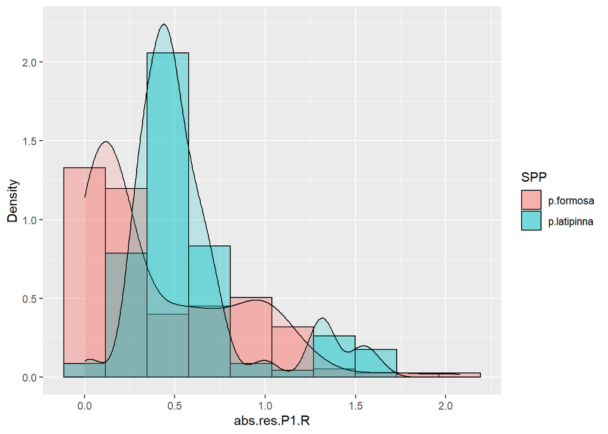

```r
plot_multi_histogram <- function(df, feature, label_column) {
    plt <- ggplot(df, aes(x=eval(parse(text=feature)), fill=eval(parse(text=label_column)))) +
    geom_histogram(bins=10, alpha=0.4, position="identity", aes(y = ..density..), color="black") +
    geom_density(alpha=0.2)  +
    labs(x=feature, y = "Density")
    plt + guides(fill=guide_legend(title=label_column))
}

plot_multi_histogram(raw4, "abs.res.P1.R", "SPP")
```

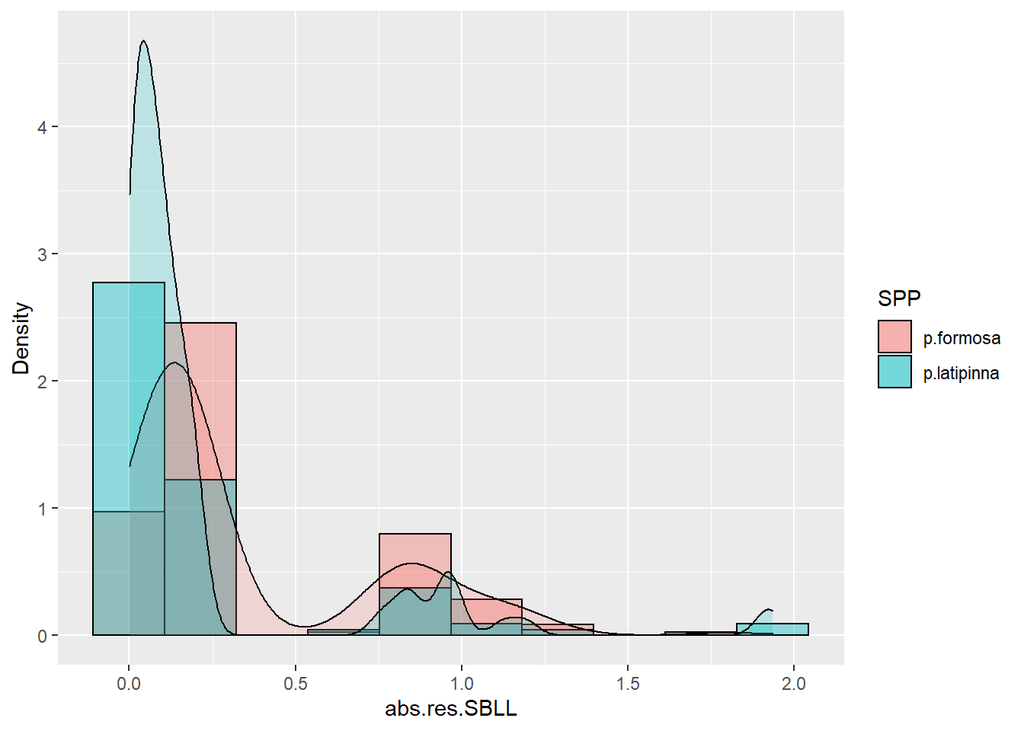

```r
plot_multi_histogram(raw4, "abs.res.SBLL", "SPP")
```

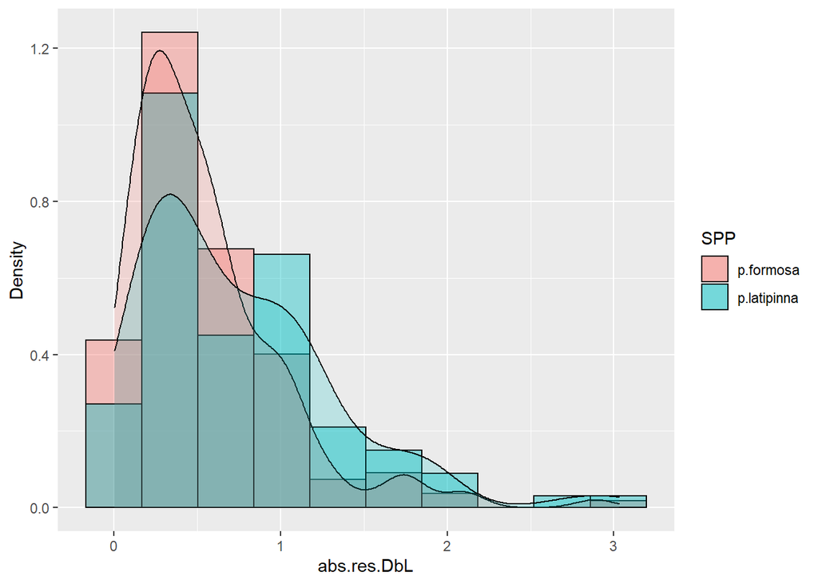

```r
plot_multi_histogram(raw4, "abs.res.DbL", "SPP")
```

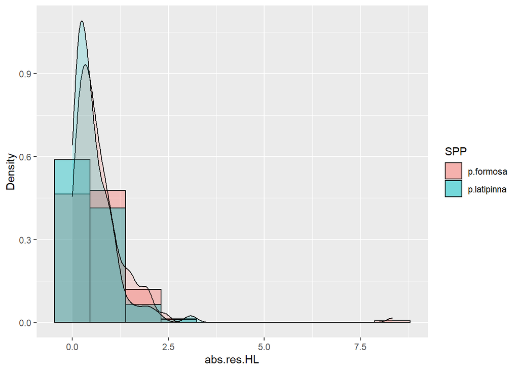

```r
plot_multi_histogram(raw4, "abs.res.HL", "SPP")
```

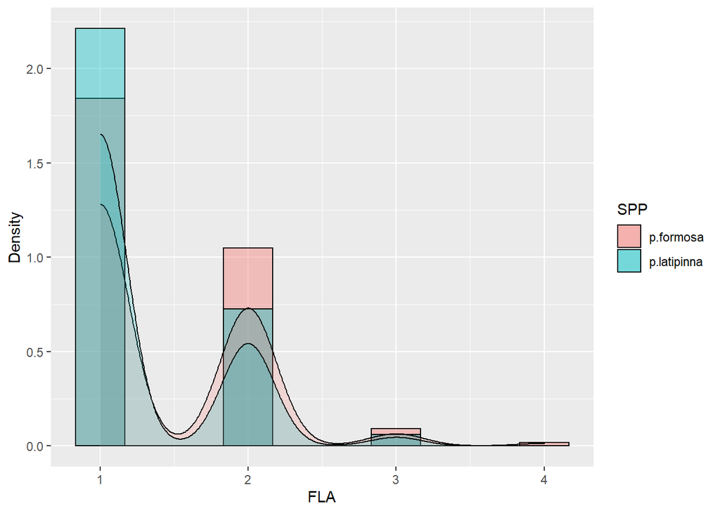

```r
plot_multi_histogram(raw4, "FLA", "SPP")
```

### ANOVA

Will run a nested ANOVA on the residuals (and raw data that isn’t affected by body size?) with location as a nested effect to see if variation is partitioned more within populations or among populations.

```r
#runs on the assumption that each subgroup has a normal distribution, check for normality among location?
#raw.q1 <- raw1[raw1$QUARTILE == "Q1",]
#raw.q2 <- raw1[raw1$QUARTILE == "Q2",]
#raw.q3 <- raw1[raw1$QUARTILE == "Q3",]
#raw.q4 <- raw1[raw1$QUARTILE == "Q4",]

#ks.test(raw.q1$CPL, "pnorm", mean=mean(raw.q1$CPL), sd=sd(raw.q1$CPL)) #NOT SIG (NORMAL)

#seems to give me a 'ties' error with NA as the p value. When looking up the error most people stated this test was useless, but that the alternatives were also useless, so idk what to do...


nest <- aov(raw4$abs.res.D ~ raw4$SPP / factor(raw4$QUARTILE))
summary(nest)
```

```
##                                 Df Sum Sq Mean Sq F value  Pr(>F)
## raw4$SPP                         1   0.00  0.0036   0.022 0.88231
## raw4$SPP:factor(raw4$QUARTILE)   6   3.61  0.6016   3.702 0.00152 **
## Residuals                      254  41.28  0.1625
## ---
## Signif. codes:  0 '***' 0.001 '**' 0.01 '*' 0.05 '.' 0.1 ' ' 1
```

```r
A.D <- aov(abs.res.D ~ SPP*QUARTILE, data=raw4)
summary(A.D)
```

```
##               Df Sum Sq Mean Sq F value   Pr(>F)
## SPP            1   0.00  0.0036   0.022 0.882311
## QUARTILE       3   0.34  0.1149   0.707 0.548711
## SPP:QUARTILE   3   3.27  1.0884   6.698 0.000229 ***
## Residuals    254  41.28  0.1625
## ---
## Signif. codes:  0 '***' 0.001 '**' 0.01 '*' 0.05 '.' 0.1 ' ' 1
```

```r
A.P1 <- aov(abs.res.P1 ~ SPP*QUARTILE, data=raw4)
summary(A.P1)
```

```
##               Df Sum Sq Mean Sq F value Pr(>F)
## SPP            1   0.14  0.1442   0.773 0.3801
## QUARTILE       3   1.18  0.3940   2.112 0.0992 .
## SPP:QUARTILE   3   0.95  0.3164   1.696 0.1683
## Residuals    254  47.39  0.1866
## ---
## Signif. codes:  0 '***' 0.001 '**' 0.01 '*' 0.05 '.' 0.1 ' ' 1
```

```r
A.P1.R <- aov(abs.res.P1.R ~ SPP*QUARTILE, data=raw4)
summary(A.P1.R)
```

```
##               Df Sum Sq Mean Sq F value Pr(>F)
## SPP            1   1.41  1.4144   9.046 0.0029 **
## QUARTILE       3   0.37  0.1220   0.780 0.5060
## SPP:QUARTILE   3   0.04  0.0119   0.076 0.9729
## Residuals    254  39.72  0.1564
## ---
## Signif. codes:  0 '***' 0.001 '**' 0.01 '*' 0.05 '.' 0.1 ' ' 1
```

```r
A.LLSC <- aov(abs.res.LLSC ~ SPP*QUARTILE, data=raw4)
summary(A.LLSC)
```

```
##               Df Sum Sq Mean Sq F value Pr(>F)
## SPP            1   0.25  0.2510   0.500 0.4803
## QUARTILE       3   4.18  1.3917   2.771 0.0422 *
## SPP:QUARTILE   3   0.54  0.1802   0.359 0.7829
## Residuals    254 127.59  0.5023
## ---
## Signif. codes:  0 '***' 0.001 '**' 0.01 '*' 0.05 '.' 0.1 ' ' 1
```

```r
A.SBLL <- aov(abs.res.SBLL ~ SPP*QUARTILE, data=raw4)
summary(A.SBLL)
```

```
##               Df Sum Sq Mean Sq F value  Pr(>F)
## SPP            1   0.96  0.9643   6.807 0.00962 **
## QUARTILE       3   0.74  0.2477   1.748 0.15759
## SPP:QUARTILE   3   0.16  0.0528   0.373 0.77268
## Residuals    254  35.98  0.1417
## ---
## Signif. codes:  0 '***' 0.001 '**' 0.01 '*' 0.05 '.' 0.1 ' ' 1
```

```r
A.BD <- aov(abs.res.BD ~ SPP*QUARTILE, data=raw4)
summary(A.BD)
```

```
##               Df Sum Sq Mean Sq F value Pr(>F)
## SPP            1   0.11  0.1106   0.329 0.5665
## QUARTILE       3   0.97  0.3231   0.963 0.4109
## SPP:QUARTILE   3   2.71  0.9032   2.691 0.0468 *
## Residuals    254  85.26  0.3357
## ---
## Signif. codes:  0 '***' 0.001 '**' 0.01 '*' 0.05 '.' 0.1 ' ' 1
```

```r
A.CPD <- aov(abs.res.CPD ~ SPP*QUARTILE, data=raw4)
summary(A.CPD)
```

```
##               Df Sum Sq Mean Sq F value  Pr(>F)
## SPP            1  0.213  0.2132   2.302 0.13043
## QUARTILE       3  1.469  0.4897   5.289 0.00149 **
## SPP:QUARTILE   3  0.043  0.0143   0.154 0.92686
## Residuals    254 23.520  0.0926
## ---
## Signif. codes:  0 '***' 0.001 '**' 0.01 '*' 0.05 '.' 0.1 ' ' 1
```

```r
A.CPL <- aov(abs.res.CPL ~ SPP*QUARTILE, data=raw4)
summary(A.CPL)
```

```
##               Df Sum Sq Mean Sq F value Pr(>F)
## SPP            1   0.00  0.0014   0.010 0.9213
## QUARTILE       3   1.52  0.5065   3.628 0.0136 *
## SPP:QUARTILE   3   0.26  0.0882   0.632 0.5950
## Residuals    254  35.45  0.1396
## ---
## Signif. codes:  0 '***' 0.001 '**' 0.01 '*' 0.05 '.' 0.1 ' ' 1
```

```r
A.PreDL <- aov(abs.res.PreDL ~ SPP*QUARTILE, data=raw4)
summary(A.PreDL)
```

```
##               Df Sum Sq Mean Sq F value Pr(>F)
## SPP            1   0.58  0.5764   3.045 0.0822 .
## QUARTILE       3   0.54  0.1809   0.956 0.4142
## SPP:QUARTILE   3   1.43  0.4751   2.509 0.0593 .
## Residuals    254  48.09  0.1893
## ---
## Signif. codes:  0 '***' 0.001 '**' 0.01 '*' 0.05 '.' 0.1 ' ' 1
```

```r
A.DbL <- aov(abs.res.DbL ~ SPP*QUARTILE, data=raw4)
summary(A.DbL)
```

```
##               Df Sum Sq Mean Sq F value Pr(>F)
## SPP            1   2.30  2.2976   8.800 0.0033 **
## QUARTILE       3   0.38  0.1262   0.483 0.6942
## SPP:QUARTILE   3   0.27  0.0903   0.346 0.7922
## Residuals    254  66.32  0.2611
## ---
## Signif. codes:  0 '***' 0.001 '**' 0.01 '*' 0.05 '.' 0.1 ' ' 1
```

```r
A.HL <- aov(abs.res.HL ~ SPP*QUARTILE, data=raw4)
summary(A.HL)
```

```
##               Df Sum Sq Mean Sq F value Pr(>F)
## SPP            1   1.65  1.6513   3.417 0.0657 .
## QUARTILE       3   3.67  1.2222   2.529 0.0578 .
## SPP:QUARTILE   3   5.07  1.6909   3.498 0.0161 *
## Residuals    254 122.77  0.4833
## ---
## Signif. codes:  0 '***' 0.001 '**' 0.01 '*' 0.05 '.' 0.1 ' ' 1
```

```r
A.HD <- aov(abs.res.HD ~ SPP*QUARTILE, data=raw4)
summary(A.HD)
```

```
##               Df Sum Sq Mean Sq F value Pr(>F)
## SPP            1  0.037 0.03695   0.313  0.576
## QUARTILE       3  0.205 0.06842   0.579  0.629
## SPP:QUARTILE   3  0.034 0.01117   0.095  0.963
## Residuals    254 30.000 0.11811
```

```r
A.HW <- aov(abs.res.HW ~ SPP*QUARTILE, data=raw4)
summary(A.HW)
```

```
##               Df Sum Sq Mean Sq F value  Pr(>F)
## SPP            1  0.007  0.0074   0.076 0.78321
## QUARTILE       3  1.411  0.4704   4.852 0.00267 **
## SPP:QUARTILE   3  0.418  0.1392   1.436 0.23271
## Residuals    254 24.626  0.0970
## ---
## Signif. codes:  0 '***' 0.001 '**' 0.01 '*' 0.05 '.' 0.1 ' ' 1
```

```r
A.SnL <- aov(abs.res.SnL ~ SPP*QUARTILE, data=raw4)
summary(A.SnL)
```

```
##               Df Sum Sq Mean Sq F value Pr(>F)
## SPP            1   0.62  0.6246   1.638 0.2018
## QUARTILE       3   1.70  0.5672   1.488 0.2184
## SPP:QUARTILE   3   4.26  1.4213   3.727 0.0119 *
## Residuals    254  96.85  0.3813
## ---
## Signif. codes:  0 '***' 0.001 '**' 0.01 '*' 0.05 '.' 0.1 ' ' 1
```

```r
A.OL <- aov(abs.res.OL ~ SPP*QUARTILE, data=raw4)
summary(A.OL)
```

```
##               Df Sum Sq Mean Sq F value Pr(>F)
## SPP            1  0.097 0.09652   2.984 0.0853 .
## QUARTILE       3  0.358 0.11933   3.688 0.0126 *
## SPP:QUARTILE   3  0.070 0.02334   0.722 0.5399
## Residuals    254  8.217 0.03235
## ---
## Signif. codes:  0 '***' 0.001 '**' 0.01 '*' 0.05 '.' 0.1 ' ' 1
```

```r
A.A <- aov(A ~ SPP*QUARTILE, data=raw4)
summary(A.A)
```

```
##               Df Sum Sq Mean Sq F value   Pr(>F)
## SPP            1   0.13  0.1348   0.667   0.4147
## QUARTILE       3   2.01  0.6709   3.321   0.0204 *
## SPP:QUARTILE   3   5.96  1.9872   9.836 3.68e-06 ***
## Residuals    254  51.31  0.2020
## ---
## Signif. codes:  0 '***' 0.001 '**' 0.01 '*' 0.05 '.' 0.1 ' ' 1
```

```r
A.SALL <- aov(SALL ~ SPP*QUARTILE, data=raw4)
summary(A.SALL)
```

```
##               Df Sum Sq Mean Sq F value   Pr(>F)
## SPP            1   0.28   0.281   1.910    0.168
## QUARTILE       3  10.05   3.351  22.771 4.34e-13 ***
## SPP:QUARTILE   3   0.32   0.108   0.732    0.534
## Residuals    254  37.37   0.147
## ---
## Signif. codes:  0 '***' 0.001 '**' 0.01 '*' 0.05 '.' 0.1 ' ' 1
```

```r
A.SBDF <- aov(SBDF ~ SPP*QUARTILE, data=raw4)
summary(A.SBDF)
```

```
##               Df Sum Sq Mean Sq F value   Pr(>F)
## SPP            1 105.95  105.95 229.998  < 2e-16 ***
## QUARTILE       3   2.93    0.98   2.122   0.0979 .
## SPP:QUARTILE   3  11.56    3.85   8.364 2.53e-05 ***
## Residuals    254 117.01    0.46
## ---
## Signif. codes:  0 '***' 0.001 '**' 0.01 '*' 0.05 '.' 0.1 ' ' 1
```

```r
A.FLA <- aov(FLA ~ SPP*QUARTILE, data=raw4)
summary(A.FLA)
```

```
##               Df Sum Sq Mean Sq F value   Pr(>F)
## SPP            1   1.32  1.3241   4.494 0.034988 *
## QUARTILE       3   5.04  1.6786   5.697 0.000865 ***
## SPP:QUARTILE   3   0.14  0.0483   0.164 0.920676
## Residuals    254  74.84  0.2946
## ---
## Signif. codes:  0 '***' 0.001 '**' 0.01 '*' 0.05 '.' 0.1 ' ' 1
```

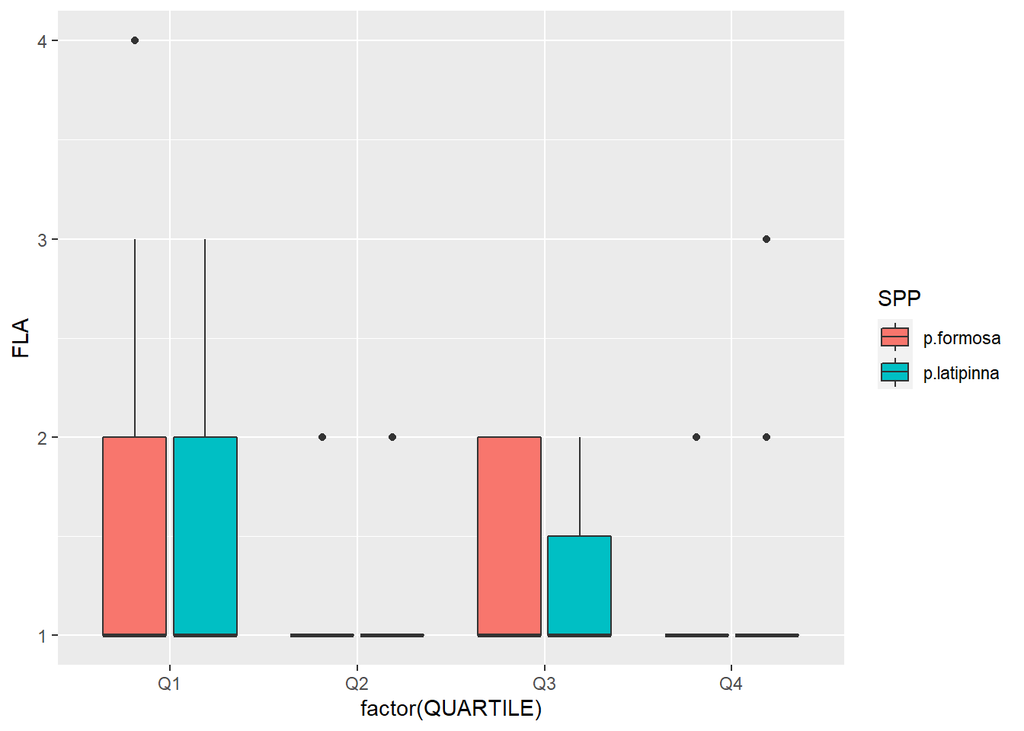

```r
ggplot(raw4, aes(x=factor(QUARTILE), y=FLA, fill=SPP)) + geom_boxplot()
```

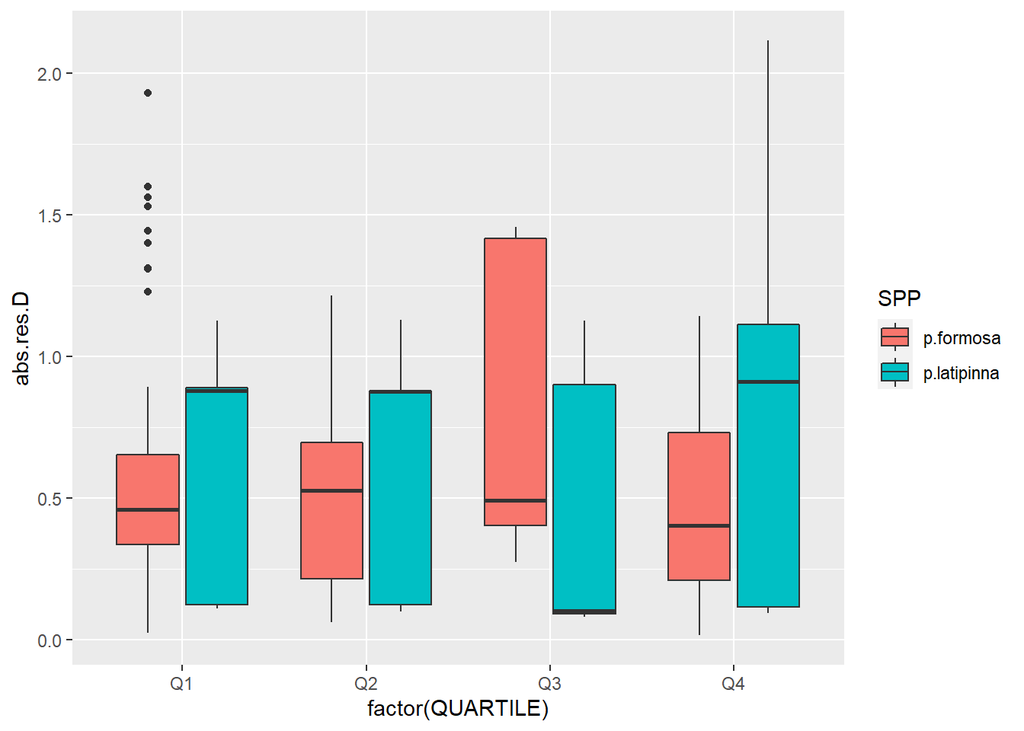

```r
library(ggplot2)


ggplot(raw4, aes(x=factor(QUARTILE), y=abs.res.D, fill=SPP)) +
  geom_boxplot()
```

```r
nest2 <- aov(raw4$abs.res.P1.R ~ raw4$SPP / factor(raw4$QUARTILE))
summary(nest2)
```

```
##                                 Df Sum Sq Mean Sq F value Pr(>F)
## raw4$SPP                         1   1.41  1.4144   9.046 0.0029 **
## raw4$SPP:factor(raw4$QUARTILE)   6   0.40  0.0669   0.428 0.8599
## Residuals                      254  39.72  0.1564
## ---
## Signif. codes:  0 '***' 0.001 '**' 0.01 '*' 0.05 '.' 0.1 ' ' 1
```

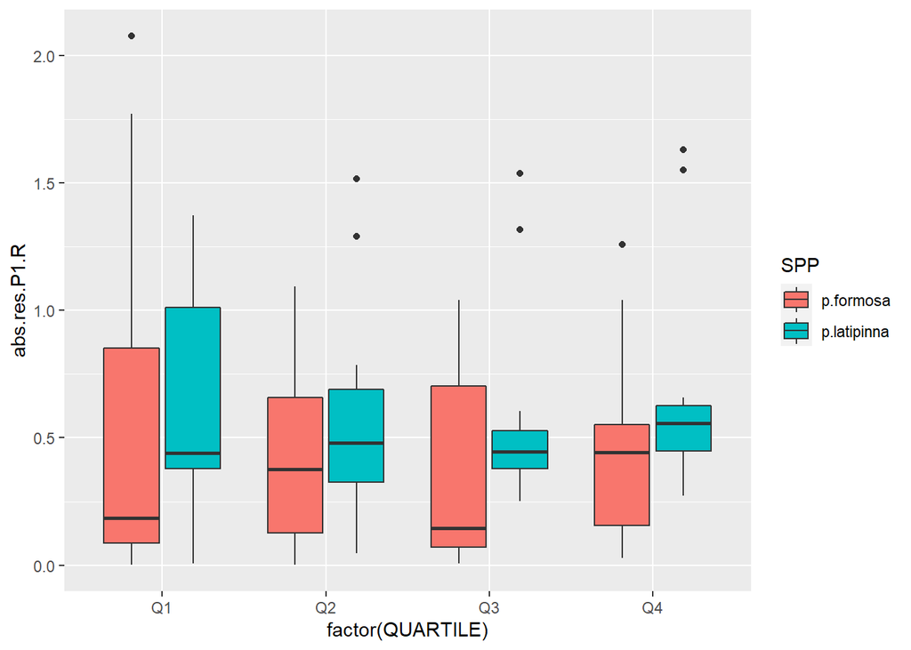

```r
ggplot(raw4, aes(x=factor(QUARTILE), y=abs.res.P1.R, fill=SPP)) +
  geom_boxplot()
```